# data-practical

## Data Analyst - Practical Test (Charter)

### COVID-19 Cases and Deaths of the United States and Worldwide

Data was obtained 6/3/2020 ~7:30 AM MST

```python
#Package Import
import numpy as np
import pandas as pd
import matplotlib.pyplot as plt
plt.style.use('fivethirtyeight')
from pylab import rcParams
rcParams['figure.figsize'] = 15, 7
import statsmodels.formula.api as sm
import os
os.chdir(r'C:\Users\TIVaw\Documents\Datacamp\Data Analyst - Practical Test (Charter)\Data-Analyst-Practical-Test-Covid--19-') #Will nt
```

Data Sets Used:

- 'Bing-COVID19-Data.csv' -- COVID-19 Data collected by Microsoft's Bing
- 'population_by_country_2020.csv' -- World population and other data provided by Kaggle user @tanuprabhu
- 'state_populations.csv' -- State population data provided by Census Bureau
- 'county_density.csv') -- County population data provided by Census Burea

```python
#Import Data Sets
bing = pd.read_csv('Data/Bing-COVID19-Data.csv')  #COVID-19 Data collected by Microsoft's Bing
pop = pd.read_csv('Data/population_by_country_2020.csv') #World population and other data provided by Kaggle user @tanuprabhu
s_pop = pd.read_csv('Data/state_populations.csv') #State population data provided by Census Bureau
c_pop = pd.read_csv('Data/county_density.csv') #County population data provided by Census Burea
```

```python
pop.rename(columns={pop.columns[0]: 'Country_Region', pop.columns[1]: 'Country_Population'}, inplace = True)
pop2 = pop.copy()
```

```python
bing_pop = bing.copy()
bing_pop = bing_pop.merge(pop2, on='Country_Region', how = 'left')
bing_pop = bing_pop.merge(s_pop, left_on='AdminRegion1', right_on='State', how = 'left')
bing_pop = bing_pop.merge(c_pop, left_on=['AdminRegion2', 'AdminRegion1'], right_on=['County', 'County_State'], how = 'left')
```

```python
world_bing = bing_pop[bing_pop['Country_Region'] != 'Worldwide']  #Removing Worldwide Specific Data
world_bing = world_bing[world_bing['Updated'] == '06/01/2020']   #Limiting to current data
world_bing['Case Ratio'] = (world_bing['Confirmed']/world_bing['Country_Population']) * 100 #Normalizing Case Count data, percent of population in country infected
world_bing['Country Pop Density'] = world_bing['Density (P/Km²)'] * 0.38610
#world_bing.to_csv('world_bing.csv')
```

```python
us_bing = bing_pop[bing_pop['Country_Region'] == 'United States']  #Creating US Specific Data Set
us_bing_all = us_bing[us_bing['AdminRegion1'].isnull()] #Dropping State Data for US Data Set, no states
us_bing_s = us_bing[us_bing['AdminRegion1'].notna()] #Creating State Specific Data
us_bing_c = us_bing_s[us_bing_s['AdminRegion2'].notna()]  #Creating County Specific Data
us_bing_c = us_bing_c[us_bing_c['County'].notna()]  #Dropping mismatched counties (minimal)
us_bing_c = us_bing_c[us_bing_c['CTYPOP'].notna()]  #Dropping mismatched counties (minimal)
us_bing_c_d = us_bing_c[us_bing_c['Updated'] == '06/01/2020']   #Limiting to current data
#us_bing_c_d['Case Ratio'] = (us_bing_c_d['Confirmed']/us_bing_c_d['CTYPOP']) * 100 #Normalizing Case Count data, percent of population in county
#us_bing_c_d.to_csv('us_bing_c_d.csv')
```

The United States started to record COVID-19 cases in the beginning of March, which has continued to increase to this day. The percentage of US Cases compared to the world's has escalated to ~30%, but has started to see a downward trend after the beginning of May. This could possibly be due to lockdowns across the country.

```python
us_cases = us_bing_all[['Updated', 'Confirmed']]
us_cases.columns = ['Updated', 'US Cases']
us_cases = us_cases[us_cases["Updated"] >= '03/01/2020']
us_cases = us_cases.set_index('Updated')
us_cases = us_cases.drop(['06/02/2020']) #Dropping row of incomplete data/extraneous data
```

```python
world_cases = world_bing[['Updated', 'Confirmed']]
world_cases.columns = ['Updated', 'Worldwide Cases']
world_cases = world_cases[world_cases["Updated"] >= '03/01/2020']
world_cases = world_cases.set_index('Updated')
```

```python
all_cases = us_cases.join(world_cases)
all_cases_d = all_cases.loc[['03/01/2020', '03/10/2020', '03/20/2020', '04/01/2020', '04/10/2020', '04/20/2020', '05/01/2020', '05/10/2020', '05/20/2020', '06/01/2020']]
all_cases_d['US Percent of World'] = (all_cases_d['US Cases'] / all_cases_d['Worldwide Cases']) * 100
all_cases_d['US Percent of World'] = all_cases_d['US Percent of World'].astype(int)
all_cases_d
```

| Updated | US Cases | Worldwide Cases | US Percent of World |
| --- | --- | --- | --- |
| 03/01/2020 | 42 | 87137 | 0 |
| 03/10/2020 | 936 | 113702 | 0 |
| 03/20/2020 | 17439 | 275130 | 6 |
| 04/01/2020 | 212747 | 932605 | 22 |
| 04/10/2020 | 493567 | 1684833 | 29 |
| 04/20/2020 | 775850 | 2470410 | 31 |
| 05/01/2020 | 1095682 | 3303296 | 33 |
| 05/10/2020 | 1320941 | 4097158 | 32 |
| 05/20/2020 | 1540294 | 4968689 | 31 |
| 06/01/2020 | 1794534 | 6246042 | 28 |

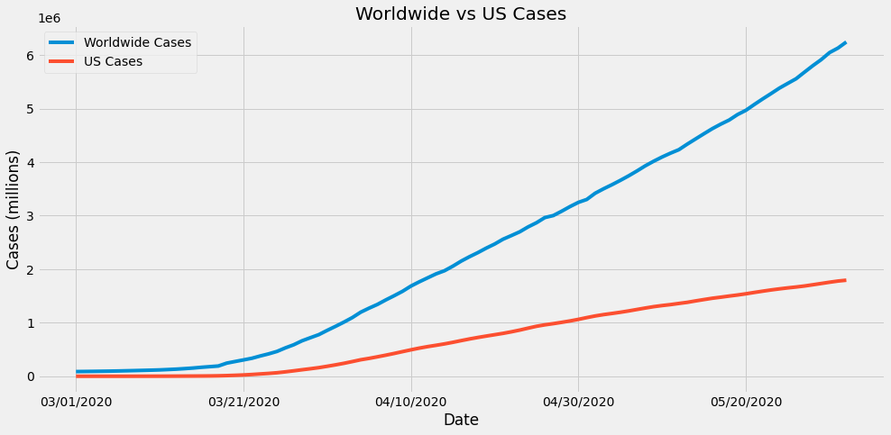

```python
ax = world_cases.plot()
us_cases.plot(ax=ax)
plt.title('Worldwide vs US Cases')
plt.xlabel('Date')
plt.ylabel('Cases (millions)')
```

```python
us_deaths = us_bing_all[['Updated', 'Deaths']]
us_deaths.columns = ['Updated', 'US Deaths']
us_deaths = us_deaths[us_deaths["Updated"] >= '03/01/2020']
us_deaths = us_deaths.set_index('Updated')
us_deaths = us_deaths.drop(['06/02/2020']) #Dropping row of incomplete data/extraneous data
```

```python
world_deaths = world_bing[['Updated', 'Deaths']]
world_deaths.columns = ['Updated', 'Worldwide Deaths']
world_deaths = world_deaths[world_deaths["Updated"] >= '03/01/2020']
world_deaths = world_deaths.set_index('Updated')
```

The Death rate of COVID-19 has seen a similar trend in the same time period, though the rate has been stagnant at ~25% since May. This could be due to US citizens having access to better healthcare than much of the rest of the world. As many factors play in to whether or not one will die after contracting COVID-19, such as age, existing health conditions, and access to modern healthcare, it is difficult to come to more conclusions with the provided data.

```python
all_deaths = us_deaths.join(world_deaths)
all_deaths_d = all_deaths.loc[['03/01/2020', '03/10/2020', '03/20/2020', '04/01/2020', '04/10/2020', '04/20/2020', '05/01/2020', '05/10/2020', '05/20/2020', '06/01/2020']]
all_deaths_d['US Percent of World'] = (all_deaths_d['US Deaths'] / all_deaths_d['Worldwide Deaths']) * 100
all_deaths_d['US Percent of World'] = all_deaths_d['US Percent of World'].astype(int)
all_deaths_d['US Deaths'] = all_deaths_d['US Deaths'].astype(int)
all_deaths_d['Worldwide Deaths'] = all_deaths_d['Worldwide Deaths'].astype(int)
all_deaths_d
```

| Updated | US Deaths | Worldwide Deaths | US Percent of World |
| --- | --- | --- | --- |
| 03/01/2020 | 4 | 2977 | 0 |
| 03/10/2020 | 34 | 4012 | 0 |
| 03/20/2020 | 233 | 11376 | 2 |
| 04/01/2020 | 4749 | 46809 | 10 |
| 04/10/2020 | 18547 | 102136 | 18 |
| 04/20/2020 | 37455 | 169794 | 22 |
| 05/01/2020 | 58931 | 235290 | 25 |
| 05/10/2020 | 73895 | 282495 | 26 |
| 05/20/2020 | 87184 | 326515 | 26 |
| 06/01/2020 | 98437 | 374452 | 26 |

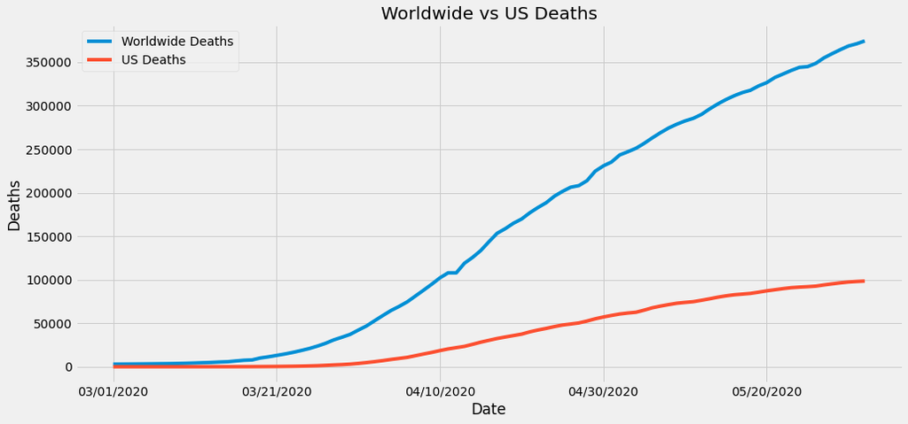

```python
ax = world_deaths.plot()
us_deaths.plot(ax=ax)
plt.title('Worldwide vs US Deaths')
plt.xlabel('Date')
plt.ylabel('Deaths')
```

--

Since the population data set provided population density information for each country, I decided to run a simple regression to see if population density of countries had any impact on the amount of COVID-19 cases within the country since it could possibly spread more easily. The regression below is the result, and it returned a p-value of 0.136, which is unacceptable as a regression model; however, you might notice that there are very strong outliers in this equation that are swaying the data to be inaccurate. Monaco, specifically, is a very populous country for it's size, being one of the smallest (and richest) countries in the world. If we remove Monaco from the equation (by clicking on the plot for Monaco and selecting 'Exclude', we suddenly see a model that we can accept with a p-value of 0.002. While this regression is acceptable, the r-squared value of 0.048 shows that population density has little to no impact at all on the amount of COVID-19 cases a country will see.

```python
%%HTML
<div class='tableauPlaceholder' id='viz1591375243853' style='position: relative'><noscript><a href='#'><img alt=' ' src='https:&#47;&#47;public.tableau.com&#47;static&#47;images&#47;Re&#47;RegressionofCountryPopulationDensityImpactonCOVID-19CasePercentage&#47;Sheet1&#47;1_rss.png' style='border: none' /></a></noscript><object class='tableauViz'  style='display:none;'><param name='host_url' value='https%3A%2F%2Fpublic.tableau.com%2F' /> <param name='embed_code_version' value='3' /> <param name='site_root' value='' /><param name='name' value='RegressionofCountryPopulationDensityImpactonCOVID-19CasePercentage&#47;Sheet1' /><param name='tabs' value='no' /><param name='toolbar' value='yes' /><param name='static_image' value='https:&#47;&#47;public.tableau.com&#47;static&#47;images&#47;Re&#47;RegressionofCountryPopulationDensityImpactonCOVID-19CasePercentage&#47;Sheet1&#47;1.png' /> <param name='animate_transition' value='yes' /><param name='display_static_image' value='yes' /><param name='display_spinner' value='yes' /><param name='display_overlay' value='yes' /><param name='display_count' value='yes' /><param name='filter' value='publish=yes' /></object></div>                <script type='text/javascript'>                    var divElement = document.getElementById('viz1591375243853');                    var vizElement = divElement.getElementsByTagName('object')[0];                    vizElement.style.width='100%';vizElement.style.height=(divElement.offsetWidth*0.75)+'px';                    var scriptElement = document.createElement('script');                    scriptElement.src = 'https://public.tableau.com/javascripts/api/viz_v1.js';                    vizElement.parentNode.insertBefore(scriptElement, vizElement);                </script>
```

[figure not shown]

--

The Bing data set included specific U.S. county data regarding COVID-19 cases as well, so I decided to run the same type of regression against population data to the case percentage of each county. The results were accepted with a minimal p-value and an r-squared of 0.06, which matches the results of the global regression as well. Again, while there were a few outliers, population density has no direct impact on the amount of cases a county might see.

```python
%%HTML
<div class='tableauPlaceholder' id='viz1591375272348' style='position: relative'><noscript><a href='#'><img alt=' ' src='https:&#47;&#47;public.tableau.com&#47;static&#47;images&#47;Re&#47;RegressionofUSCountyPopulationDensityImpactonCOVID-19CasePercentage&#47;Sheet1&#47;1_rss.png' style='border: none' /></a></noscript><object class='tableauViz'  style='display:none;'><param name='host_url' value='https%3A%2F%2Fpublic.tableau.com%2F' /> <param name='embed_code_version' value='3' /> <param name='site_root' value='' /><param name='name' value='RegressionofUSCountyPopulationDensityImpactonCOVID-19CasePercentage&#47;Sheet1' /><param name='tabs' value='no' /><param name='toolbar' value='yes' /><param name='static_image' value='https:&#47;&#47;public.tableau.com&#47;static&#47;images&#47;Re&#47;RegressionofUSCountyPopulationDensityImpactonCOVID-19CasePercentage&#47;Sheet1&#47;1.png' /> <param name='animate_transition' value='yes' /><param name='display_static_image' value='yes' /><param name='display_spinner' value='yes' /><param name='display_overlay' value='yes' /><param name='display_count' value='yes' /><param name='filter' value='publish=yes' /></object></div>                <script type='text/javascript'>                    var divElement = document.getElementById('viz1591375272348');                    var vizElement = divElement.getElementsByTagName('object')[0];                    vizElement.style.width='100%';vizElement.style.height=(divElement.offsetWidth*0.75)+'px';                    var scriptElement = document.createElement('script');                    scriptElement.src = 'https://public.tableau.com/javascripts/api/viz_v1.js';                    vizElement.parentNode.insertBefore(scriptElement, vizElement);                </script>
```

[figure not shown]

--

Things to keep in mind:

- Data from China was excluded from the regression models as no population or population density data was provided. This could play a major factor in the results as this is where COVID-19 originated, though China has been reporting rather low numbers as of late.
- This data is dependent upon actual testing numbers. Since not every human has been tested, the numbers could drastically change as it is a possibility that humans can have COVID-19 but remain asymptomatic.
- The regression models were created only off the most recent data, and different countries are experiencing different timelines of infection rates. A possible change to the data would be to take the 'max' amount of cases at any given recorded time.
- Different countries have different lockdown/preventative measures. While some countries have taken the lockdown very seriously, others have been more lackadaisical approach.
- It is very possible that there will be a second wave of cases in many countries including the United States. I plan to create a forecast with the fbprophet python package to predict how the trend might sway in the next few months, especially given the protests going on throughout the country currently. The result of the protests could very well accelerate a new wave of COVID-19 cases across the country.